# TP de MNB

Clément MALLERET, Alexis SONOLET

## Question 1 :

$$p(y, \theta) = \frac{1}{16 \pi} exp \left( -\frac{1}{32} (8y^2 - 4 y \theta + \theta ^2) \right)$$
On a :
$$8y^2 - 4y\theta + \theta ^2 = 8\left( y \ - \ \frac{\theta}{4} \right)^2 + \frac{\theta ^2}{2}$$
Ainsi :
$$p(y, \theta) = -\frac{1}{16 \pi} exp \left( -\frac{1}{4} \left( y - \frac{\theta}{4} \right) ^2 + \frac{\theta ^2}{64} \right)$$
$$p(y, \theta) = -\frac{1}{16 \pi} exp \left( - \frac{ \left( y - \frac{\theta}{4} \right) ^2 }{2 (\sqrt 2) ^2} \right) exp \left( - \frac{ \theta ^2 }{2 (4\sqrt 2) ^2} \right)$$

Alors on peut identifier plusieurs parties :

1. La partie en
   $$\frac{1}{2 \sqrt \pi} exp \left( - \frac{ \left( y - \frac{\theta}{4} \right) ^2 }{2 (\sqrt 2) ^2} \right)$$
   suit une loi normale
   $$N \left( \frac{\theta}{4}, \sqrt 2 \right)$$
   .
2. La partie en
   $$\frac{1}{8 \sqrt \pi} exp \left( - \frac{ \theta ^2 }{2 (4\sqrt 2) ^2} \right)$$
   suit une loi normale
   $$N \left( 0, 4 \sqrt 2 \right)$$
   .

Par identification avec la loi :
$$p(y, \theta) = p(\theta) * p(y | \theta)$$
Alors :
$$p(y | \theta)$$
suit une loi normale
$$N \left( \frac{\theta}{4}, \sqrt 2 \right)$$
$$p(\theta)$$
suit une loi normale
$$N \left( 0, 4 \sqrt 2 \right)$$

## Question 2 :

En réitérant le même procédé qu’à la question 1, mais en isolant $y$ au lieu de $\theta$, on trouve :
$$p(y, \theta) = -\frac{1}{16 \pi} exp \left( - \frac{ \left( \theta - 2y \right) ^2 }{2 (4) ^2} \right) exp \left( - \frac{ y ^2 }{2 (2) ^2} \right)$$
Comme on a de plus :
$$p(y, \theta) = p(\theta | y) * p(y)$$
Alors :
$$p(\theta | y)$$
suit une loi normale
$$N \left( 2y, 4 \right)$$
$$p(y)$$
suit une loi normale
$$N \left( 0, 2 \right)$$

## Question 3 :

Pour simuler un tirage selon la loi de densité $p(y, \theta)$, on simule celle de $\theta$ puis on l’utilise pour simuler la loi suivant $p(y | \theta)$ :

```r
simulation_theta <- function(n){
  tirage_theta = rnorm(n, 0, 4 * sqrt(2))
  return(tirage_theta)
}

simulation_y <- function(tirage_theta){
  tirage_y = c()
  for(theta in tirage_theta){
    tirage_y = c(tirage_y, rnorm(1, theta / 4, sqrt(2)))
  }
  return(tirage_y)
}

simulation <- function(n){
    theta <- simulation_theta(n)
    y <- simulation_y(theta)
    return(data.frame(y, theta))
}
```

## Question 4 :

On a vu que $p(\theta | y)$ suit une loi normale : son espérance est $2y$.

## Question 5 et 6:

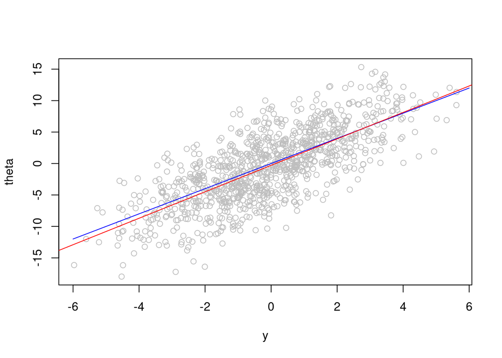

```r
tirage <- simulation(1000)
plot(tirage, type = "p", col = "grey")
lines((-6:6), 2 * (-6:6), type = "l", col = "blue")


# Question 6

#On cr?e le modèle lin?aire
reg_lin <- lm(tirage[,2] ~ tirage[,1])
#On affiche la droite de r?gression lin?aire
abline(reg_lin, col = "red")
```

## Question 7

```r
#on simule les tirages
tirage <- simulation(100000)
```

```r
#On filtre les valeurs qui ne remplissent pas la condition
selection <- tirage[tirage$y > 1.99,]
selection <- selection[selection$y < 2.01,]
selection
```

|  | y | theta |
| --- | --- | --- |
| 290 | 1.995012 | 5.60570055 |
| 312 | 1.993927 | 1.07710970 |
| 385 | 2.006115 | 1.86000626 |
| 1046 | 2.001375 | 4.70647195 |
| 1057 | 2.004858 | 12.70311586 |
| 1597 | 1.993135 | 6.65413836 |
| 2405 | 2.003832 | -0.69920462 |
| 2452 | 2.001655 | 5.47868034 |
| 2529 | 2.005170 | 4.19426013 |
| 2639 | 1.992971 | 3.54372065 |

[output cut: 232 more lines]

## Question 8

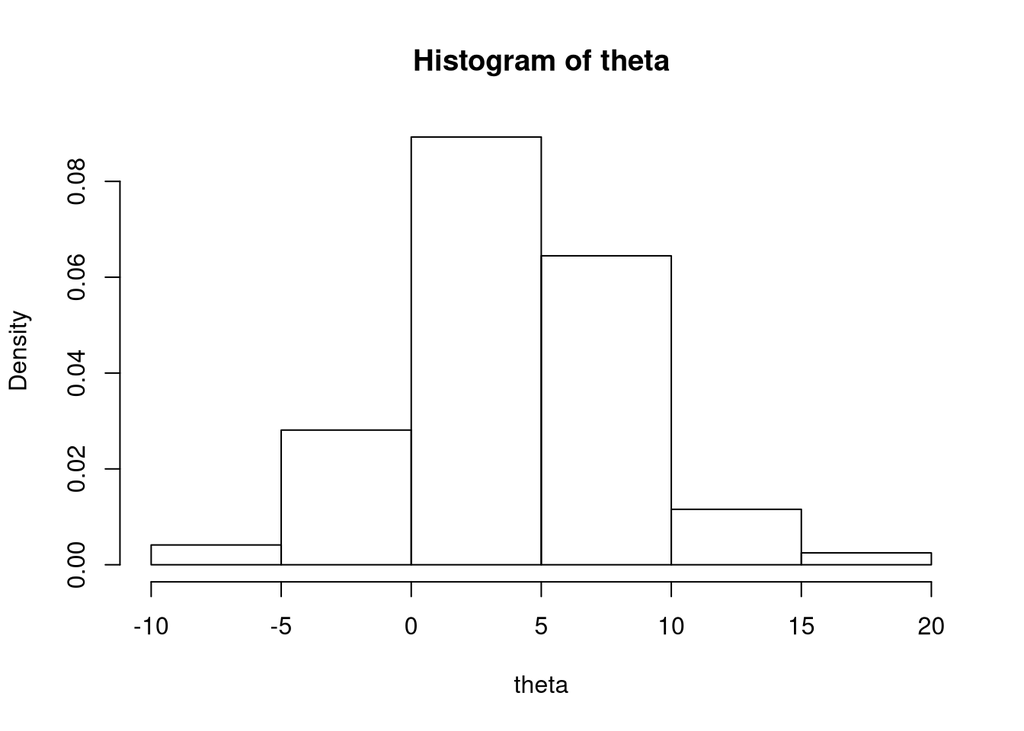

```r
theta = selection[,2]
hist(theta, freq = FALSE)
```

## Question 10

```r
Gibbs <- function(n, nb_val_eleminees, theta0 = 0){
    theta_t <- theta0 #Initialisation de theta

    theta <- c() #vecteur stockant les valeurs de theta
    y <- c() #vecteur stockant les valeurs de y

    #On doit it?rer n fois, plus le nombre de valeurs que l'on veut ?liminer
    #en d?but d'algorithme pour perdre les condition initiales
    for (t in 1:(n + nb_val_eleminees)){
        y_t <- rnorm(1, theta_t / 4, sqrt(2)) # On simule y_t
        theta_t <- rnorm(1, 2 * y_t, 4) # On simule theta_t

        #On ajoute les nouvelles valeurs aux vecteurs si on a ?limin? assez de valeurs
        if (t > nb_val_eleminees){
            theta <- c(theta, theta_t)
            y <- c(y, y_t)
        }
    }
    return(data.frame(y, theta))
}
```

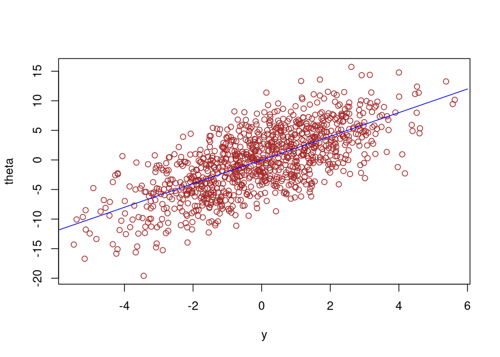

```r
#On ?limine la 1e valeur seulement
gibbs1 <- Gibbs(1000, 1)
plot(gibbs1, col = "brown")
lines((-6:6), 2 * (-6:6), type = "l", col = "blue")
```

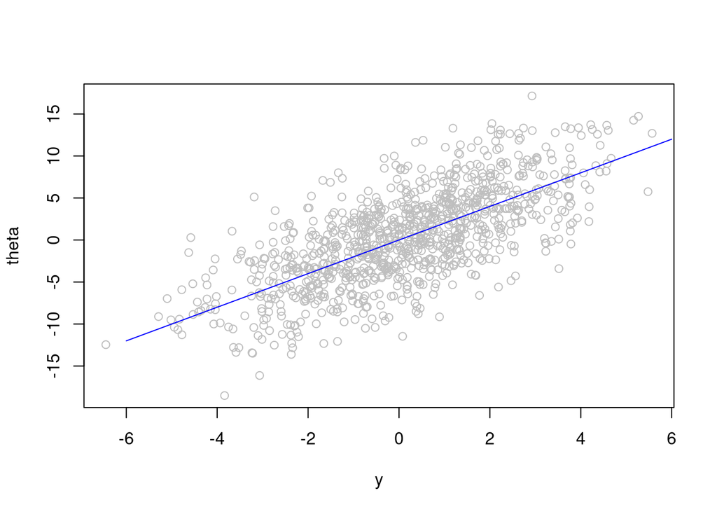

```r
#On ?limine les 10 premi?res valeurs
gibbs10 <- Gibbs(1000, 10)
plot(gibbs10, col = "grey")
lines((-6:6), 2 * (-6:6), type = "l", col = "blue")
```

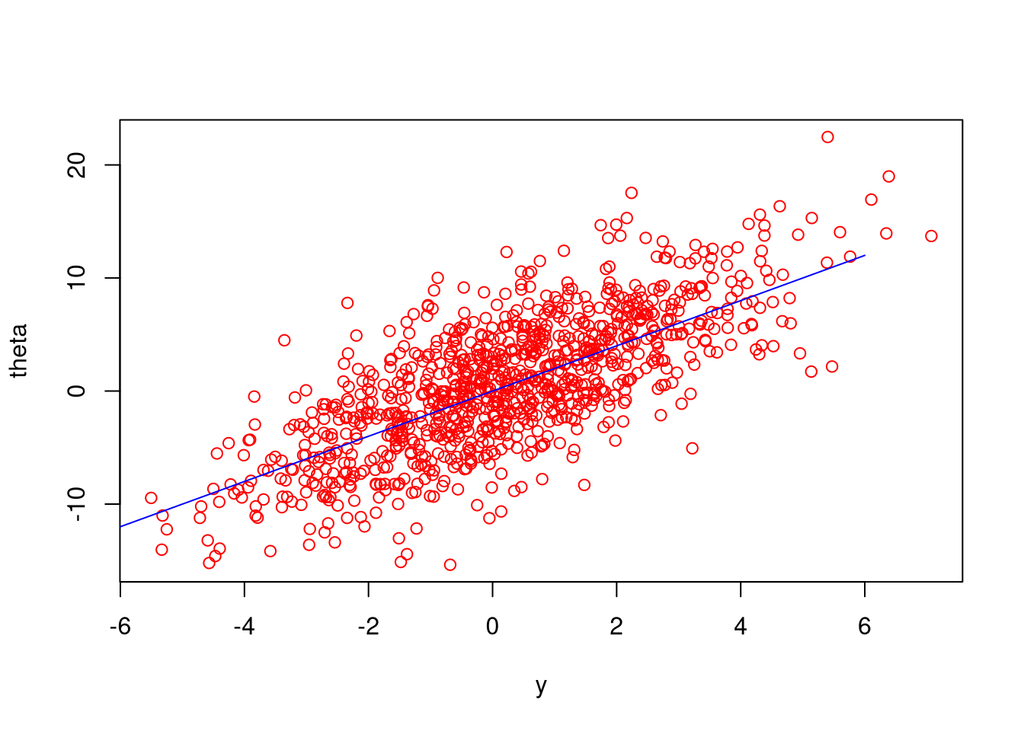

```r
#On ?limine les 100 premi?res valeurs
gibbs100 <- Gibbs(1000, 100)
plot(gibbs100, col = "red")
lines((-6:6), 2 * (-6:6), type = "l", col = "blue")
```

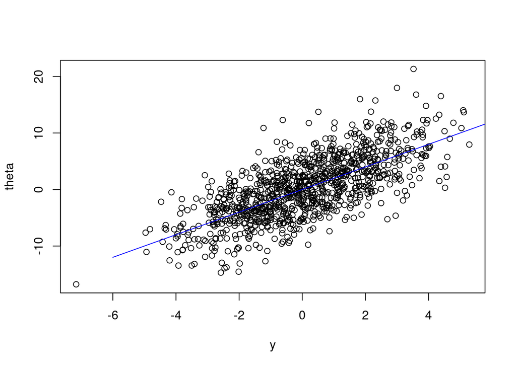

```r
#On ?limine les 500 premi?res valeurs
gibbs500 <- Gibbs(1000, 500)
plot(gibbs500, col = "black")
lines((-6:6), 2 * (-6:6), type = "l", col = "blue")
```

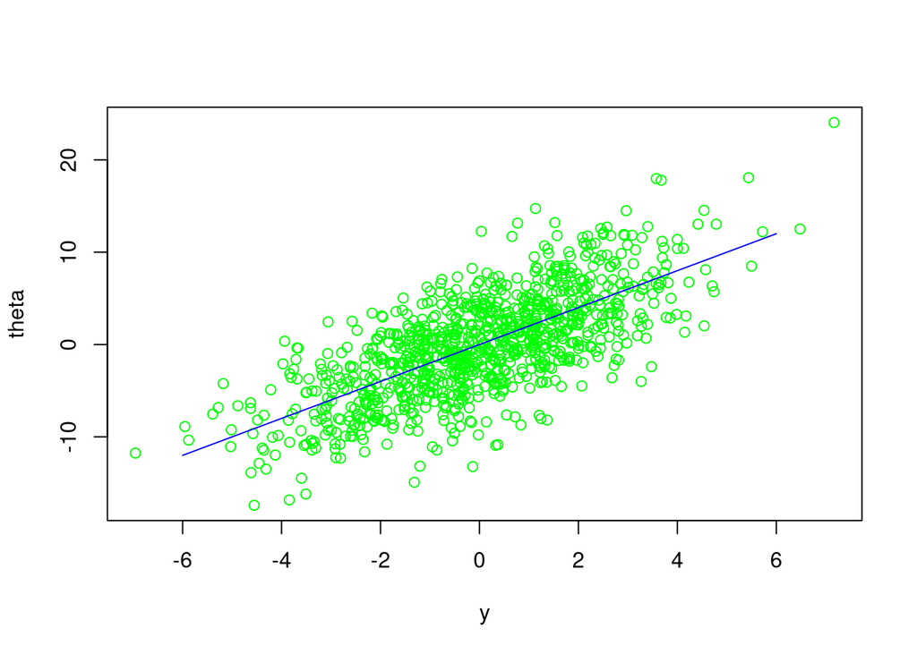

```r
#On ?limine les 10000 premi?res valeurs
gibbs10000 <- Gibbs(1000, 10000)
plot(gibbs10000, col = "green")
lines((-6:6), 2 * (-6:6), type = "l", col = "blue")
```

Ainsi, on peut voir que le nombre de valeurs éliminées ne semble pas influer sur l’algorithme. De plus, les résultats par cet algorithme correspondent très bien à ce qui a été calculé : cet algorithme permet donc de simuler la loi de $(\theta, y)$, avec pour donnée seulement $p(\theta | y)$ et $p(y | \theta)$.